#### Сафронова Анна, azsafronova

## Анализ причин ухода сотрудников

Логичнее всего мне показалось выделить подгруппу наиболее результативных работников (PerformanceRating - “Outstanding”,“Excellent”) - поскольку именно их увольнение по идее должно приносить бизнесу максимальные убытки, так что изменение влияющих на их увольнение факторов помогло бы сэкономить предприятию средства.

```r
all = dbGetQuery(con, "SELECT EmployeeNumber, Department, EnvironmentSatisfaction,
                       JobRole, MonthlyIncome, YearsSinceLastPromotion, Attrition, Age, Gender, DistanceFromHome, Education, YearsAtCompany, JobInvolvement

                       FROM portfolio INNER JOIN profile USING(EmployeeNumber)")

d = data.frame ('Выборка'  = c("вся выборка", "продуктивные работники"), 'Число_наблюдений' = c(as.numeric(nrow(all)), as.numeric(nrow(dbGetQuery(con, "SELECT EmployeeNumber, Department, EnvironmentSatisfaction,
                                 JobRole, MonthlyIncome, YearsSinceLastPromotion, Attrition, Age,                                                    Gender, DistanceFromHome, Education, YearsAtCompany, JobInvolvement

                                 FROM portfolio INNER JOIN profile USING(EmployeeNumber)

                                 WHERE PerformanceRating = 'Outstanding' | 'Excellent'")))))

knitr::kable(d)
```

| Выборка | Число_наблюдений |
| --- | --- |
| вся выборка | 1058 |
| продуктивные работники | 1058 |

Оказалось, что в наших данных отсутствуют “Low” и “Good” оценки результативности. В связи с этим было принято решение заменить анализ работников по показателю продуктивности анализом по показателю зарплаты. Эти переменные по сути отражают одно и то же, поскольку в большинстве случаев как раз наиболее производительные сотрудники получают максимальную зарплату. Таким образом, в исследовании был выделен сегмент работников с показателями зарплаты (переменная MonthlyIncome) выше медианного значения (4903,5).

Посмотрим на распределение данных в генеральной совокупности и в выделенном сегменте.

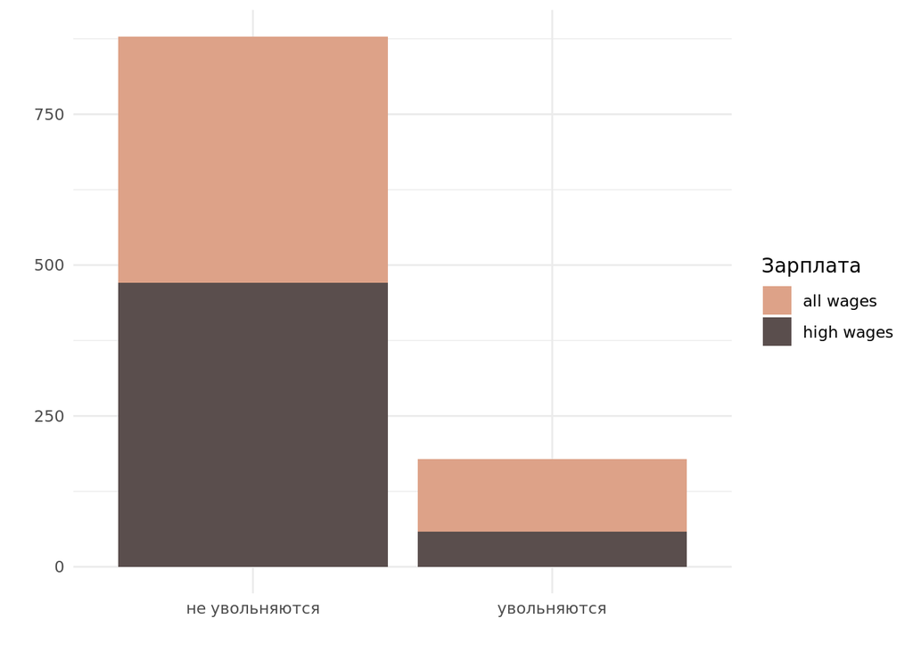

```r
high = all %>% filter((dbGetQuery(con, "SELECT EmployeeNumber, MonthlyIncome FROM portfolio"))$MonthlyIncome >= median((dbGetQuery(con, "SELECT EmployeeNumber, MonthlyIncome FROM portfolio"))$MonthlyIncome))


#график без легенды зато сос мыслом..

#ggplot(data = high) +
#      geom_bar(data = all, aes(x = as.factor(Attrition)), fill = "#DDA288") +
#      geom_bar(aes(x = as.factor(Attrition)), fill = "#5A4E4D") +
#    theme_minimal() + xlab('Attrition') + ylab('') + scale_x_discrete(labels = c('не увольняются', #'увольняются'))


all_n = all %>% mutate(Wages = ifelse(MonthlyIncome >= median(MonthlyIncome), 'high wages', 'all wages'))
ggplot(data = all_n) +
geom_bar(aes(x = as.factor(Attrition), fill = Wages)) +
theme_minimal() + xlab('') + ylab('') + scale_fill_manual(values = c("#DDA288", "#5A4E4D")) +
guides(fill = guide_legend(title = "Зарплата")) +
scale_x_discrete(labels = c('не увольняются', 'увольняются'))
```

```r
h = 100*(high %>% group_by(Attrition) %>% summarise(n = n()))[2,2]/
       ((high %>% group_by(Attrition) %>% summarise(n = n()))[2,2] +
        (high %>% group_by(Attrition) %>% summarise(n = n()))[1,2])

a = 100*(all %>% group_by(Attrition) %>% summarise(n = n()))[2,2]/
       ((all %>% group_by(Attrition) %>% summarise(n = n()))[2,2] +
        (all %>% group_by(Attrition) %>% summarise(n = n()))[1,2])

dd = data.frame('Зарплата'  = c("all wages", "high wages"), 'Увольняются' = c(paste(round(a$n, digits = 2), '%'), paste(round(h$n, digits = 2), '%')))
knitr::kable(dd)
```

| Зарплата | Увольняются |
| --- | --- |
| all wages | 16.92 % |
| high wages | 10.96 % |

Приступим к построению моделей. На рассмотрение было взято 4 типа моделей: Logistic Regression, Random Forest, Boosting и Decision Tree. Выбор модели будет основываться на характеристике accuracy для тестовой и обучающей выборки.

```r
### ПОСТРОЕНИЕ МОДЕЛЕЙ

outstanding_model = high %>% na.omit()

outstanding_model$Department = as.factor(outstanding_model$Department)
outstanding_model$EnvironmentSatisfaction = as.factor(outstanding_model$EnvironmentSatisfaction)
outstanding_model$JobRole = as.factor(outstanding_model$JobRole)
outstanding_model$Attrition = as.factor(outstanding_model$Attrition)
outstanding_model$JobInvolvement = as.factor(outstanding_model$JobInvolvement)
outstanding_model$Education = as.factor(outstanding_model$Education)
outstanding_model$Gender = as.factor(outstanding_model$Gender)

set.seed(24601)
split = initial_split(outstanding_model, prop = 0.8)
train = training(split)
test = testing(split)

# Logistic Regression
log = logistic_reg(mode = 'classification') %>% set_engine('glm')
wf_log = workflow() %>% add_model(log) %>% add_formula(Attrition ~ .) %>% fit(train)
predtest_log = predict(wf_log, test)
accuracy_log = accuracy_vec(test$Attrition, predtest_log$.pred_class)

predtrain_log = predict(wf_log, train)
accuracy_log.tr = accuracy_vec(train$Attrition, predtrain_log$.pred_class)

# ------------------------------------------------------------------------------

# Tree
tree = decision_tree(mode = 'classification') %>% set_engine('rpart')
wf_tree = workflow() %>% add_model(tree) %>% add_formula(Attrition ~ .) %>% fit(train)
predtest_tree = predict(wf_tree, test)
accuracy_tree = accuracy_vec(test$Attrition, predtest_tree$.pred_class)

predtrain_tree = predict(wf_tree, train)
accuracy_tree.tr = accuracy_vec(train$Attrition, predtrain_tree$.pred_class)

# ------------------------------------------------------------------------------

# Random Forest
rf = rand_forest(mode = 'classification', trees = 50) %>% set_engine('randomForest')
wf_rf = workflow() %>% add_model(rf) %>% add_formula(Attrition ~ .) %>% fit(train)
predtest_rf = predict(wf_rf, test)
accuracy_rf = accuracy_vec(test$Attrition, predtest_rf$.pred_class)

predtrain_rf = predict(wf_rf, train)
accuracy_rf.tr = accuracy_vec(train$Attrition, predtrain_rf$.pred_class)

#можно еще так
#rf = rand_forest(mode = "classification") %>% set_engine("randomForest") %>% fit(Attrition ~ ., data = train)
#predtest_rf = predict(rf$fit, test)
#accuracy_rf = accuracy_vec(test$Attrition, predtest_rf)

# ------------------------------------------------------------------------------

# Boosting
xgb = boost_tree(mode = "classification") %>% set_engine("xgboost") %>% fit(Attrition ~ ., data = train)
predtest_xgb = predict(xgb, test)
accuracy_xgb = accuracy_vec(test$Attrition, predtest_xgb$.pred_class)

predtrain_xgb = predict(xgb, train)
accuracy_xgb.tr = accuracy_vec(train$Attrition, predtrain_xgb$.pred_class)




### ПРОВЕРКА ПОКАЗАТЕЛЕЙ МОДЕЛЕЙ, ВЫБОР МОДЕЛИ

accuracy = c('Logistic Regression' = accuracy_log, 'Decision Tree' = accuracy_tree, 'Random Forest' = accuracy_rf, 'Boosting' = accuracy_xgb)
accuracy.tr = c('Logistic Regression' = accuracy_log.tr, 'Decision Tree' = accuracy_tree.tr, 'Random Forest' = accuracy_rf.tr, 'Boosting' = accuracy_xgb.tr)

ddd = data.frame('Accuracy_Test' = accuracy, 'Accuracy_Train' = accuracy.tr) %>% arrange(-accuracy)
knitr::kable(ddd)
```

|  | Accuracy_Test | Accuracy_Train |
| --- | --- | --- |
| Logistic Regression | 0.8679245 | 0.8912530 |
| Random Forest | 0.8584906 | 1.0000000 |
| Boosting | 0.8396226 | 0.9881797 |
| Decision Tree | 0.8301887 | 0.9101655 |

Все модели, кроме Logistic Regression и, возможно, Decision Tree оказались переобучены. Рассмотрим характеристики sensitivity и specificity для не переобученных моделей.

```r
test1 = test %>% mutate(Prediction = predtest_log$.pred_class)
metrics1 = test1 %>% conf_mat(truth = Attrition, estimate = Prediction) %>% summary()
metrics_log = metrics1 %>% filter(.metric == 'sens' | .metric == 'spec') %>% select(-.estimator)

test2 = test %>% mutate(Prediction = predtest_tree$.pred_class)
metrics2 = test2 %>% conf_mat(truth = Attrition, estimate = Prediction) %>% summary()
metrics_tree = metrics2 %>% filter(.metric == 'sens' | .metric == 'spec') %>% select(-.estimator)

metrics = c('sensitivity', 'specificity')
dddd = data.frame('Metric' = metrics, 'Logistic_Regression' = metrics_log$.estimate, 'Decision_Tree' = metrics_tree$.estimate)

knitr::kable(dddd)
```

| Metric | Logistic_Regression | Decision_Tree |
| --- | --- | --- |
| sensitivity | 0.9891304 | 0.9456522 |
| specificity | 0.0714286 | 0.0714286 |

Что ж, эти показатели не подходят для построения релевантных прогнозов. Возможно, такие значения получились в силу несбалансированности выборки. Построим модели Logistic Regression и Decision Tree на сбалансируемой методом UP-SAMPLING выборке.

```r
### ПРОВЕРКА СБАЛАНСИРОВАННОСТИ ВЫБОРКИ

t = table(train$Attrition)

table = table(train$Attrition)[1]/table(train$Attrition)[2]

# 0 встречается в 8.6 раз чаще, чем 1
#для построения лучшей модели, воспользуемся методом UP-SAMPLING для балансировки выборки


ds_up = recipe( ~ ., data = train) %>%
  step_upsample(Attrition) %>%
  prep(training = train, retain = TRUE) %>%
  bake(new_data = NULL)

row = nrow(ds_up)
#в изначальной выборке 423 наблюдения, в полученной - 758

wf_log.up = workflow() %>% add_model(log) %>% add_formula(Attrition ~ .) %>% fit(ds_up)
wf_tree.up = workflow() %>% add_model(tree) %>% add_formula(Attrition ~ .) %>% fit(ds_up)

new_predtest_log = wf_log.up %>% predict(test)
new_predtest_tree = wf_tree.up %>% predict(test)

metrics3 = test %>% cbind(new_predtest_log) %>% conf_mat(Attrition, .pred_class) %>% summary()
metrics_log3 = metrics3 %>% filter(.metric == 'sens' | .metric == 'spec' | .metric == 'accuracy') %>% select(-.estimator)

metrics4 = test %>% cbind(new_predtest_tree) %>% conf_mat(Attrition, .pred_class) %>% summary()
metrics_log4 = metrics4 %>% filter(.metric == 'sens' | .metric == 'spec' | .metric == 'accuracy') %>% select(-.estimator)

metrics = c('accuracy', 'sensitivity', 'specificity')
ddddd = data.frame('Metric' = metrics, 'Logistic_Regression' = metrics_log3$.estimate, 'Decision_Tree' = metrics_log4$.estimate)

knitr::kable(ddddd)
```

| Metric | Logistic_Regression | Decision_Tree |
| --- | --- | --- |
| accuracy | 0.6509434 | 0.7075472 |
| sensitivity | 0.6847826 | 0.7717391 |
| specificity | 0.4285714 | 0.2857143 |

Рассмотрим ее подробнее. Определим, какие переменные она считает наиболее значимыми в определении статуса увольнения сотрудника.

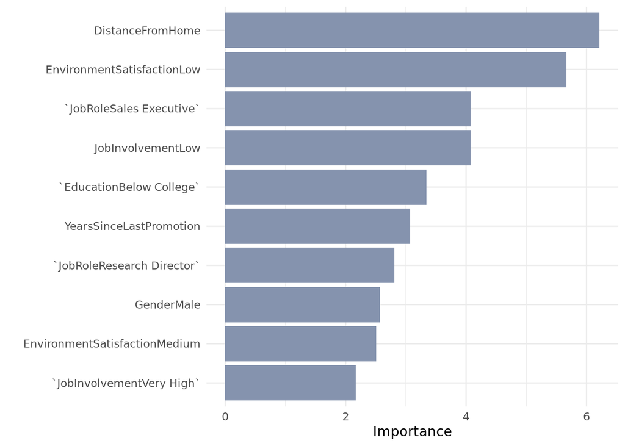

```r
wf_log.up %>% extract_fit_parsnip() %>% vip(aesthetics = list(fill = "#8593AE")) + theme_minimal()
```

Большое расстояние до работы а также низкая удовлетворенность окружением оказались наиболее важными для предсказания моделью переменной Attrition.

Получается, для того, чтобы снизить число увольняющихся, необходимо: во-первых, улучшить рабочее окружение, а во-вторых, арендовать жилье для работников рядом с офисом.

Смоделируем ситуацию улучшения окружения, поскольку скорее всего расходы работодателя от данного действия будут меньше, чем от аренды жилья. Узнаем, насколько сильно уменьшится процент увольняющихся - т.е. какую потенциальную прибыль может сохранить нововведение.

Предположим, нововведение подействовало так, что все работники, дающие окружению низкую оценку, поменяли свое мнение. Так что в выборке теперь все оценки принимают значение “Very High”.

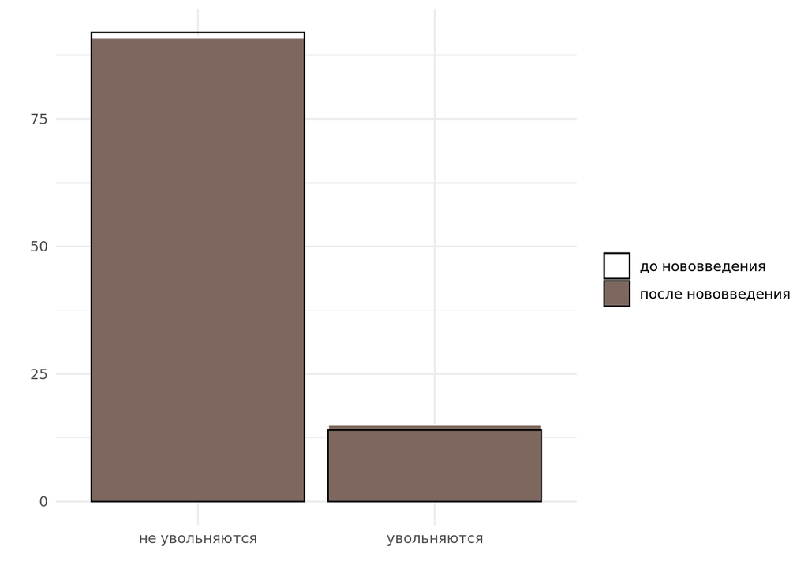

```r
test_simulation = test

EnvironmentSatisfaction = case_when(test_simulation$EnvironmentSatisfaction == 'Low' ~ 'Very High',
                                    test_simulation$EnvironmentSatisfaction == 'Medium' ~ 'Very High',
                                    test_simulation$EnvironmentSatisfaction == 'High' ~ 'Very High',
                                    test_simulation$EnvironmentSatisfaction == 'Very High' ~ 'Very High')


test_simulation$EnvironmentSatisfaction = EnvironmentSatisfaction


predTest = predict(wf_log.up, test_simulation)$.pred_class

test4488 = test %>% rename(predTest = Attrition)
ggplot(NULL, aes(x = predTest)) +
geom_bar(data = data.frame(predTest), aes(fill = "после нововведения"), alpha = 1, col = 'white') +
geom_bar(data = test4488, aes(fill = 'до нововведения'), alpha = 0, col = 'black') +
scale_fill_manual(values = c("white", "#7E675E")) +
guides(fill = guide_legend(title = "")) +
scale_x_discrete(labels = c('не увольняются', 'увольняются')) + theme_minimal() + xlab('') + ylab('')
```

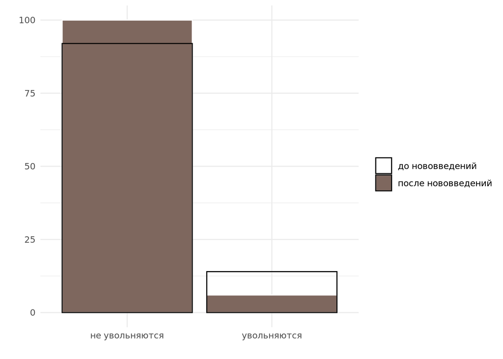

```r
test_simulation = test
test_simulation$DistanceFromHome = as.numeric(test_simulation$DistanceFromHome)
test_simulation$DistanceFromHome = ifelse(test_simulation$DistanceFromHome>=5, 5, test_simulation$DistanceFromHome)

test_simulation$DistanceFromHome = as.integer(test_simulation$DistanceFromHome)
EnvironmentSatisfaction = case_when(test_simulation$EnvironmentSatisfaction == 'Low' ~ 'Very High',
                                    test_simulation$EnvironmentSatisfaction == 'Medium' ~ 'Very High',
                                    test_simulation$EnvironmentSatisfaction == 'High' ~ 'Very High',
                                    test_simulation$EnvironmentSatisfaction == 'Very High' ~ 'Very High')

test_simulation$EnvironmentSatisfaction = EnvironmentSatisfaction

predTest = predict(wf_log.up, test_simulation)$.pred_class

ggplot(NULL, aes(x = predTest)) +
geom_bar(data = data.frame(predTest), aes(fill = "после нововведений"), alpha = 1, col = 'white') +
geom_bar(data = test4488, aes(fill = 'до нововведений'), alpha = 0, col = 'black') +
scale_fill_manual(values = c("white", "#7E675E")) +
guides(fill = guide_legend(title = "")) +
scale_x_discrete(labels = c('не увольняются', 'увольняются')) + theme_minimal() + xlab('') + ylab('')
```

Как видно из графика, количество увольняющихся работников действительно значительно снизилось.